# EDA

```r
library(rpart)
library(tree)
library(MASS)
library(rpart.plot)
library(tidyverse)
library(dplyr)

citydata <- read.csv("col_citydata.csv", header = TRUE)

#creating a new data frame where we have only one row per city instead of multiple city rows
rows_to_cols <- citydata %>% spread(metrics, price)

#renaming the columns to shorter names
colnames(rows_to_cols) <- c("city", "apt_in_center", "apt_out_center", "salary", "basics", "internet", "meal_for_2", "inexpensive_meal")



full <- read.csv(file = "full_col_data.csv", header = TRUE)

#extracting only the three additional metrics I want to study from the full data frame
subset <- full %>% filter(metrics == "McMeal at McDonalds (or Equivalent Combo Meal)" | metrics == "Gasoline (1 gallon)" | metrics == "International Primary School, Yearly for 1 Child")


#transforming subset to data frame with one row per city
subset2 <- subset %>% spread(metrics, price)
colnames(subset2) <- c("city", "gas", "primary_school", "mcmeal")

#combining the two new data frames I just created.
combined <- left_join(rows_to_cols, subset2, by = "city")
```

We will do some exploratory analysis of the data to try to get a sense of the relationship between average monthly salary and each of the other predictor variables

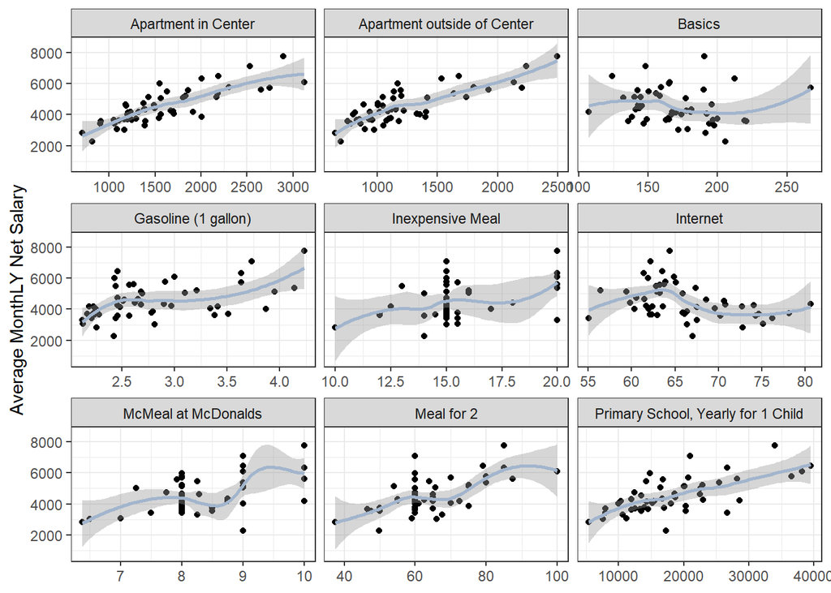

```r
combined %>%
  gather(predictor, value, c(apt_in_center, apt_out_center, basics, internet, meal_for_2, inexpensive_meal, gas, primary_school, mcmeal)) %>%
  ggplot(aes(x = value, y = salary)) +
  geom_point() +
  geom_smooth(color = "lightsteelblue3") +
  facet_wrap(~ predictor, scales = 'free_x', labeller =
               as_labeller(c("apt_in_center" = "Apartment in Center",
                             "apt_out_center" = "Apartment outside of Center",
                             "basics" = "Basics",
                             "inexpensive_meal" = "Inexpensive Meal",
                             "internet" = "Internet",
                             "meal_for_2" = "Meal for 2",
                             "gas" = "Gasoline (1 gallon)",
                             "primary_school" = "Primary School, Yearly for 1 Child",
                             "mcmeal" = "McMeal at McDonalds"))) +
  xlab(NULL) + ylab("Average MonthLY Net Salary") +
  theme_bw()
```

There seems to be a positive relationship between the average monthly net salary and the price of an apartment in the center, the price of an apartment outside of the center, the price of a meal for two in a mid-range restaurant, the price of 1 gallon of gasoline, the price of a McMeal at McDonalds, and the tuition for 1 child at an international primary school.

However, looking at the plots, there does not seem to be a significant relationship between the average monthly net salary and the price of the basic utilities (such as electricity, heating, cooling, water, and garbage), the price of the Internet, and the price of an inexpensive meal.

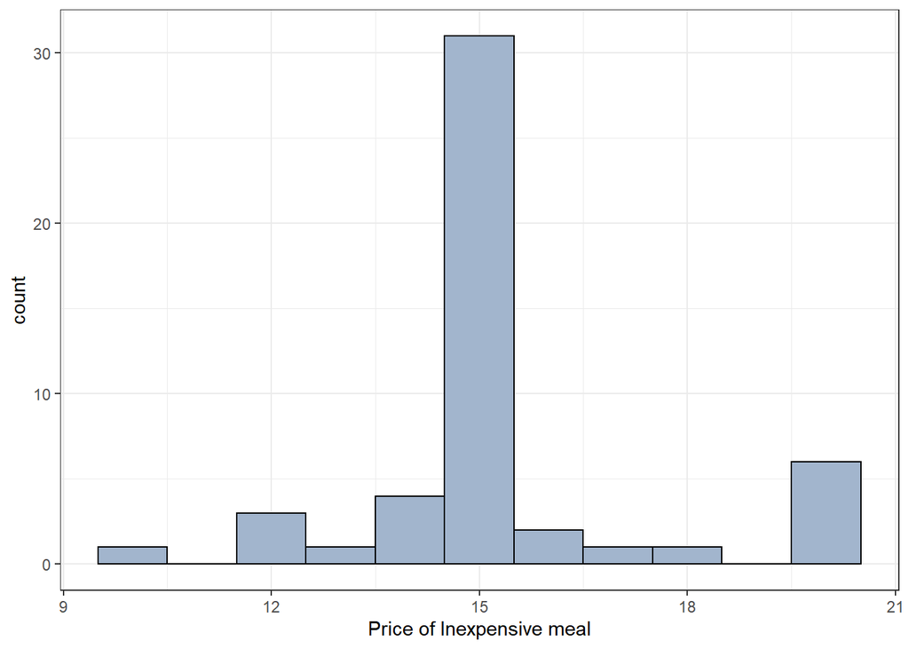

```r
combined %>% ggplot() +
  geom_histogram(aes(x = inexpensive_meal), binwidth = 1, color = "black", fill = "lightsteelblue3") +
  labs(x = "Price of Inexpensive meal")+
  theme_bw()
```

It seems that most cities have the same average price for an inexpensive meal (around $15) which explains why there is no significant relationship between the average monthly net salary and the price of an inexpensive meal.

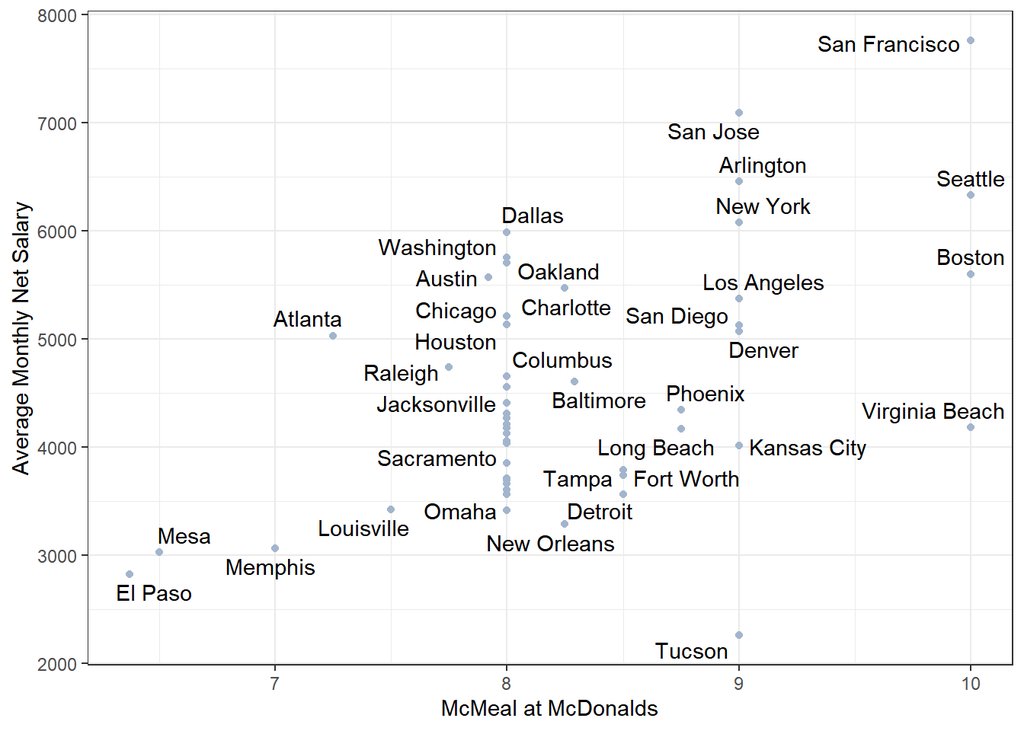

```r
library(ggrepel)
combined %>% ggplot(aes(x = mcmeal, y = salary, label = city)) +
  geom_point(color = "lightsteelblue3")+
  geom_text_repel()+
  labs( x = "McMeal at McDonalds", y = "Average Monthly Net Salary")+
  theme(legend.position = "none")+
  theme_bw()
```

Our second focus is the apartment price in city center since it could best reflect the standard of living. When considering job offer, people would prefer to live near city center for convenience, and the price may deviated a lot in different cities. First, we will get a sense about how city center price differ from each city.

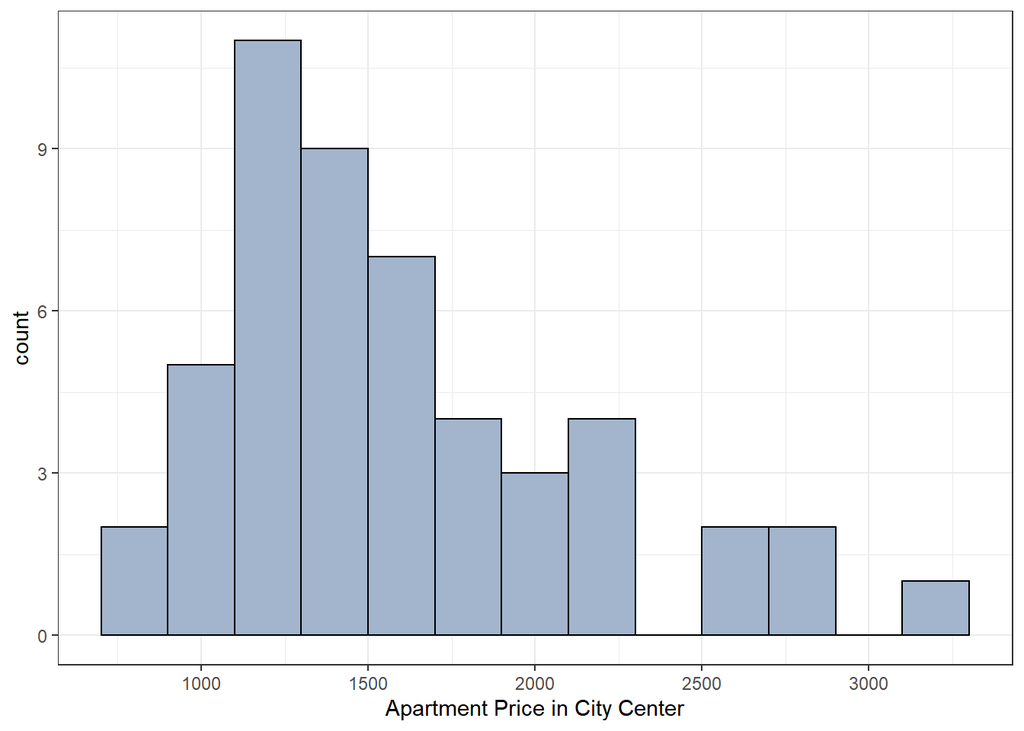

```r
#Histogram for Apartment Price in City Center
combined %>% ggplot() +
  geom_histogram(aes(x = apt_in_center), binwidth = 200, color = "black", fill = "lightsteelblue3") +
  labs(x = "Apartment Price in City Center")+
  theme_bw()
```

Based on the histogram, we could see the distribution of apartment price in city center is skewed to the right a little bit,indicating that the price of an apartment in the city center for most cities is between 1200 and 2000. There are some outliers which indicates that some cities have exceptionally large prices of apartments inside of the center. Below we are going to check which cities correspond to these outliers.

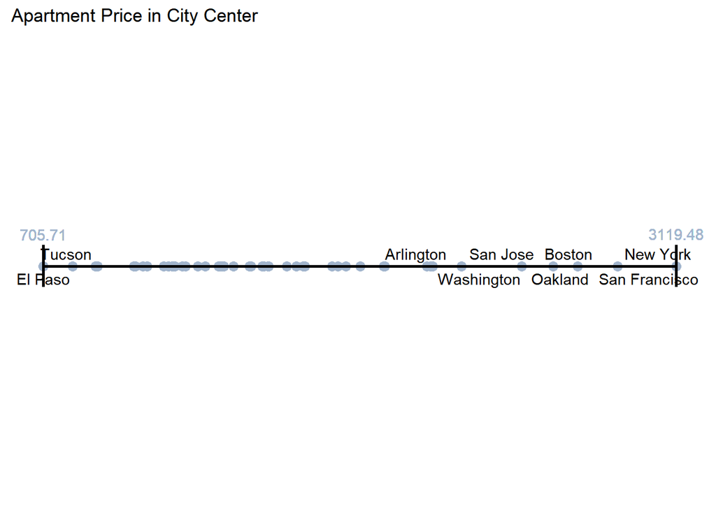

```r
combined %>% ggplot(aes(x = apt_in_center, y=0, label = city)) +
  geom_point(size = 3, color = "lightsteelblue3")  +
  annotate("segment",x=705.71,xend=3119.48, y=0, yend=0, size=1) +
  annotate("segment",x=705.71,xend=705.71, y=-0.1,yend=0.1, size=1) +
  annotate("segment",x=3119.48,xend=3119.48, y=-0.1,yend=0.1, size=1) +
  geom_text_repel()+
  scale_x_continuous(limits = c(705,3120)) +
  scale_y_continuous(limits = c(-1,1)) +
  scale_color_manual(values = unname(colours)) +
  theme(panel.background = element_blank(),
        axis.text = element_blank(),
        axis.ticks = element_blank(),
        axis.title = element_blank())+
  ggtitle("Apartment Price in City Center")+
  geom_text(label = "705.71", x = 705.71, y = 0.15, color = "lightsteelblue3") +
  geom_text(label = "3119.48", x = 3119.48, y = 0.152, color = "lightsteelblue3")
```

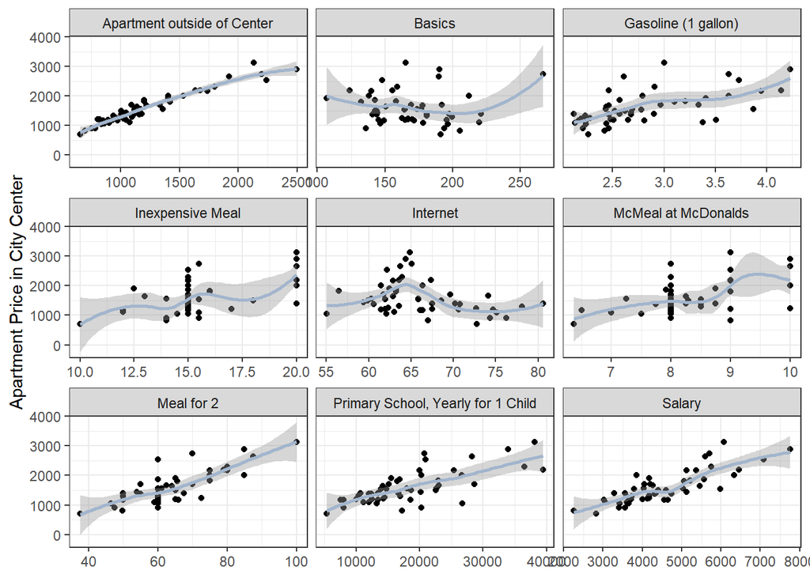

```r
#Draw the relationship between apt in city center and predicted variables
combined %>%
  gather(predictor, value, c(apt_out_center, salary, basics, internet, meal_for_2, inexpensive_meal, gas, primary_school, mcmeal)) %>%
  ggplot(aes(x = value, y = apt_in_center)) +
  geom_point() +
  geom_smooth(color = "lightsteelblue3") +
  facet_wrap(~ predictor, scales = 'free_x', labeller =
               as_labeller(c("apt_out_center" = "Apartment outside of Center",
                             "basics" = "Basics",
                             "salary" = "Salary",
                             "inexpensive_meal" = "Inexpensive Meal",
                             "internet" = "Internet",
                             "meal_for_2" = "Meal for 2",
                             "gas" = "Gasoline (1 gallon)",
                             "primary_school" = "Primary School, Yearly for 1 Child",
                             "mcmeal" = "McMeal at McDonalds"))) +
  xlab(NULL) + ylab("Apartment Price in City Center")+
  theme_bw()
```

From the above plot, we could see that most variables have positive linear relationship with apartment price in city center, and the predictors include apartment outside of city center, gasoline, inexpensive meal, McMeal at McDonalds, meal for 2, primary school, and salary. Basics (Electricity, Heating, Cooling, Water, Garbage for 915 sq ft Apartment) seem to have a quadratic relationship with apartment price in city center. Internet does not have clear relationship with apartment price.

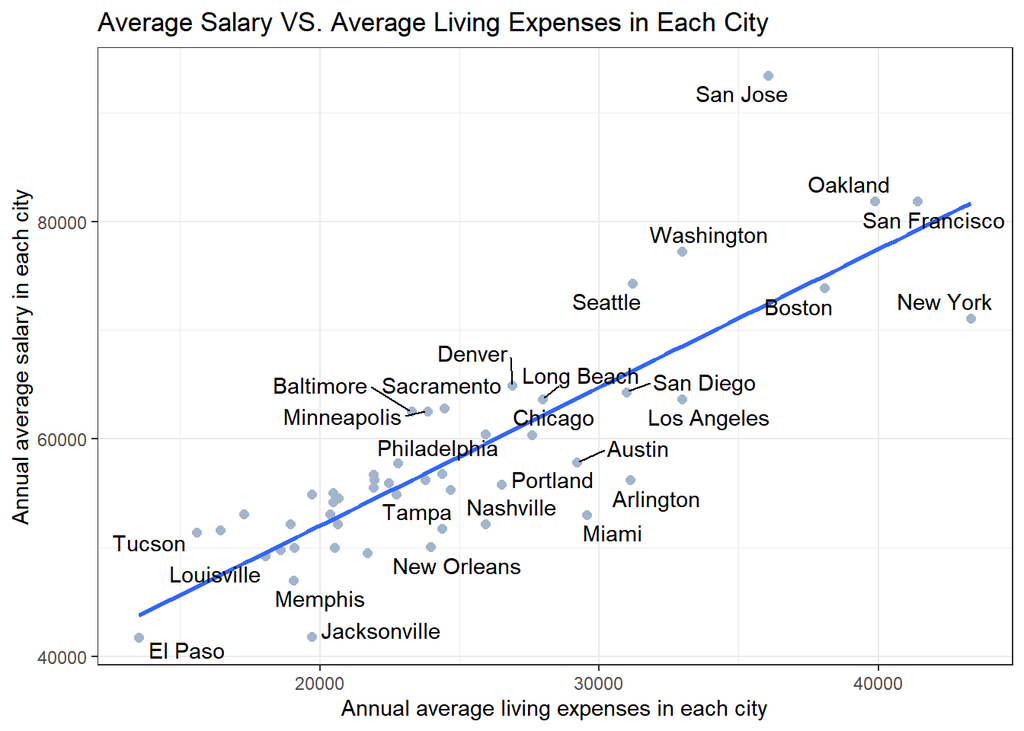

```r
salary_expenses_byCity <- read.csv("salary_expenses_byCity.csv", header = TRUE)

salary_expenses_byCity %>% ggplot(aes(x = AnnualExpenses, y = AnnualSalary , label = city)) +
  geom_point(aes(x = AnnualExpenses, y = AnnualSalary, label = city), size = 2, color = "lightsteelblue3") +
  geom_smooth(method = lm, se = FALSE)+
  geom_text_repel() +
  xlab("Annual average living expenses in each city") +
  ylab("Annual average salary in each city") +
  ggtitle("Average Salary VS. Average Living Expenses in Each City") +
  theme_bw()
```

According to the scatter plot, we can see that there is a clear trade-off between average salary and average living expenses in each city in the USA. Generally speaking, in the cities where people have higher annual average salary, the annual average living expenses will also be higher.

Comparing Boston and New York in this plot, we can see that Boston has a higher annual average salary while lower annual average living expenses. In this sense, Boston is more comfortable to live in than New York. Cities with highest annual average salaries are San Jose, San Francisco, and Oakland. All of the three are in the Bay area. Comparing the three cities, San Jose is the most comfortable to live in.